# nequip

## [Molecular Dynamics with NeQUIP](https://github.com/mir-group/nequip) [[Colab Notebook](https://colab.research.google.com/drive/1_r348f6oIyKxH4FnpKeD8g4QjwDhP8mT?usp=sharing)]

#### Required Libraries : [numpy](https://pypi.org/project/numpy/), nequip, [ase](https://pypi.org/project/ase/), [matplotlib](https://pypi.org/project/matplotlib/)

This tutorial introduces a Machine Learning Interatomic Potential (MLP) model called NequIP.

1. Data generation
2. Training
3. Molecular Dynamics

For data generation, we will use the [Quantum Espresso](https://www.quantum-espresso.org/) package.

Here, I am not going to explain how to generate the initial configuration. However, there are several ways to do that. The easiest way is to perform a classical MD simulation and then take the (M) random configurations and do the *ab-initio* calculations to get the potential energy and corresponding forces (in this case, we will be using Quantum Espresso).

The initial 500 configurations (input and output) are stored in the **QE_In_File** and **QE_Out_File** folders inside the *00.data* directory. (You can re-run the inputs if you want).

The underlying concept and details are given in this [article](https://doi.org/10.1038/s41467-022-29939-5) [https://www.nature.com/articles/s41467-022-29939-5].

```python
import os
from ase.io import read, write
import numpy as np
import matplotlib.pyplot as plt
# Import ASE library for read and write
import ase
from ase import Atoms
from ase.calculators.espresso import Espresso
```

```python
# store current working directory path in prefix_path variable
prefix_path = os.getcwd()
#print(prefix_path)
#!ls
```

```python
# change working directory
os.chdir(
    os.path.join(prefix_path, 'water', '00.data')
)
#! pwd
```

A Python script (*file_xyz_QE.py*) is provided under the root directory to convert XYZ trajectory file to QE input.

```
❯ ls nequip_tutorial
file_xyz_QE.py  nequip.ipynb  nequip.pdf  water
```

## 1. Training data for NeQUIP

```python
# Since I have already ran the ab-inito calculations and the output files are stored in QE_Out_file,
# I am going to skip that part and directly moving to data extraction.

#os.system(f"mkdir -p {'training_data'}")

# Initialize lists to store data
coordinates = []  # coordinates (MxNx3) M-frames N-atoms 3-dimension(x y z)
energies    = []  # energies (M-frames)
forces      = []  # forces on each atom (MxNx3) M-frames N-atoms 3-dimension(x y z)
types       = []  # Atom types

# Setting box size [fix box size for all the configurations]
box_sizes   = np.array([[40.06, 0, 0],
                     [0, 40.06, 0],
                     [0, 0, 40.06]])
# Periodic boundary Condition
pbc = (True, True, True)
#
w_name = np.array(b'water_qe')
w_theory = np.array(b'')
w_type = np.array(b'd')

# Total number of data frames (Quantum Espresso output)
n_frames = 500
# Loop over each frame and extract data
for idx in range(n_frames):  # Adjust the range as needed
    try:
        conf = ase.io.read('QE_Out_file/pw-wt-' + str(idx) + '.out', format='espresso-out')
    except Exception as e:
        print(f"Error reading configuration {idx}: {e}")
    else:
        try:
            conf.get_forces()  # Check if forces are available
        except Exception as e:
            print(f"Forces missing from file {idx}: {e}")
        else:
            # Extract and append data to lists
            coordinates.append(conf.get_positions())
            energies.append(conf.get_potential_energy())
            forces.append(conf.get_forces())
#            virials.append(conf.get_stress(voigt=False))
#            box_sizes.append(conf.get_cell())
            if len(types) == 0:  # Extract atom types only once
                types = np.array(conf.get_chemical_symbols())
                types[types == "H"] = "1"
                types[types == "O"] = "8"

# Save data to NPZ file
np.savez('water-22.npz', E=energies, name='water_qe', pbc=pbc,
         cell=box_sizes, R=coordinates, F=forces, theory=w_theory, type=w_type, z=types)
```

```python
!ls
```

```
QE_In_File    QE_Out_File   training_data water-22.npz
```

```python
# Load the dataset file and see what's inside
data = np.load('water-22.npz')
```

```python
data.files
```

```
['E', 'name', 'pbc', 'cell', 'R', 'F', 'theory', 'type', 'z']
```

```python
# Print various dataset and check if the dimensions are correct.
#
print("Energy.shape: ", data['E'].shape, '[dimension - M]')
print("Coord.shape: ", data['R'].shape, '[dimension - M x N x 3]')
print("Forces.shape: ", data['F'].shape, '[dimension - M x N x 3]')
print("Atomic Number: ", data['z'], '(44 => Hydrogen, 22 => Oxygen)')
print("Cell dimension: ", data['cell'])
print("Periodic Boundary Condition:", data['pbc'], '(axis-XYZ)')
```

```
Energy.shape:  (500,) [dimension - M]
Coord.shape:  (500, 66, 3) [dimension - M x N x 3]
Forces.shape:  (500, 66, 3) [dimension - M x N x 3]
Atomic Number:  ['1' '1' '1' '1' '1' '1' '1' '1' '1' '1' '1' '1' '1' '1' '1' '1' '1' '1'
 '1' '1' '1' '1' '1' '1' '1' '1' '1' '1' '1' '1' '1' '1' '1' '1' '1' '1'
 '1' '1' '1' '1' '1' '1' '1' '1' '8' '8' '8' '8' '8' '8' '8' '8' '8' '8'
 '8' '8' '8' '8' '8' '8' '8' '8' '8' '8' '8' '8'] (44 => Hydrogen, 22 => Oxygen)
Cell dimension:  [[40.06  0.    0.  ]
 [ 0.   40.06  0.  ]
 [ 0.    0.   40.06]]
Periodic Boundary Condition: [ True  True  True] (axis-XYZ)
```

## 2. Training (NeQUIP)

```python
os.chdir(
    os.path.join(prefix_path,'water', '01.train')
)
# !pwd
# !ls
```

### some important keywords in training (YAML) file: `train.yaml`

The *key_mapping* keywords are default to the nequip, which has to be correctly mapped. Therefore, we need to carefully store the values while creating the dataset in `npz` file.

```
In our case, the data stored at `water.npz` file: ['E', 'name', 'pbc', 'cell', 'R', 'F', 'theory', 'type', 'z'],

where, E => potential energy, R => cartesian coordinates, F => forces, etc.
```

```
key_mapping:
  z: atomic_numbers     # atmoic species (integer)
  E: total_energy       # total potential energy
  F: forces             # atomic forces
  R: pos                # atomic positions
  pbc: pbc              # periodic boundary condition
  cell: cell
npz_fixed_field_keys:
  - atomic_numbers
  - cell
  - pbc

# A list of atomic types to be found in the data. The NequIP types will be named with the chemical symbols, and
# inputs with the correct atomic numbers will be mapped to the corresponding types.
# (eg. 1:H, 8:O)
chemical_symbols:
 - H
 - O
.
.
.
# training (80/20)
n_train: 400           # number of training data
n_val: 100             # number of validation data
learning_rate: 0.0005  # learning rate (values between 0.01 and 0.005 found to be a good choice)
batch_size: 1          # batch size
max_epochs: 60         # stop training after _ number of epochs
.
.
.
# output metrics
metrics_components:
  - - forces                  # key
    - mae                     # "rmse" or "mae"
  - - forces
    - rmse
    - PerSpecies: True
      report_per_component: False
  - - forces
    - mae
    - PerSpecies: True
      report_per_component: False
  - - total_energy
    - mae
    - PerAtom: True            # If Ture, energy is normalized by the number of atoms
```

### Before we start training we need to install NeQUIP (training) and LAMMPS (MD simulation)

# Local Install (NeQUIP):

```
# install wandb (Not necessary)
!pip install wandb
# install nequip
!git clone --depth 1 "https://github.com/mir-group/nequip.git"
!pip install nequip/
# fix colab imports
import site
site.main()
# set to allow anonymous WandB
import os
os.environ["WANDB_ANONYMOUS"] = "must"
import numpy as np
import torch
from ase.io import read, write
np.random.seed(0)
torch.manual_seed(0)
```

# Install (LAMMPS):

```
# compile lammps
!git clone -b stable_29Sep2021_update2 --depth 1 https://github.com/lammps/lammps.git
!wget "https://github.com/mir-group/pair_nequip/archive/main.zip"
!unzip -q main.zip
!rm main.zip
!mv pair_nequip-main pair_nequip
!cd pair_nequip && ./patch_lammps.sh ../lammps
!pip install mkl mkl-include
!cd lammps && mkdir -p build && cd build && cmake ../cmake -DCMAKE_PREFIX_PATH=`python -c 'import torch;print(torch.utils.cmake_prefix_path)'` && make -j4
```

```python
! nequip-train --help
```

```
usage: nequip-train [-h] [--equivariance-test [EQUIVARIANCE_TEST]]
                    [--model-debug-mode] [--grad-anomaly-mode] [--log LOG]
                    config

Train (or restart training of) a NequIP model.

positional arguments:
  config                YAML file configuring the model, dataset, and other
                        options

optional arguments:
  -h, --help            show this help message and exit
  --equivariance-test [EQUIVARIANCE_TEST]
                        test the model's equivariance before training on n
                        (default 1) random frames from the dataset
  --model-debug-mode    enable model debug mode, which can sometimes give much
                        more useful error messages at the cost of some speed.
                        Do not use for production training!
  --grad-anomaly-mode   enable PyTorch autograd anomaly mode to debug NaN
                        gradients. Do not use for production training!
  --log LOG             log file to store all the screen logging
```

### Begin Training

```python
! nequip-train train.yaml
```

```
Torch device: cpu
Number of weights: 265816
Number of trainable weights: 265816
Successfully re-loaded the data set of type NpzDataset(500)...
! Starting training ...

validation
# Epoch batch         loss       loss_f       loss_e        f_mae     H_f_rmse     O_f_rmse psavg_f_rmse      H_f_mae      O_f_mae  psavg_f_mae      e/N_mae
      0     1        0.917        0.913       0.0036        0.669         0.79         1.05        0.922        0.597        0.812        0.705       0.0554
      0     2        0.999        0.996      0.00312         0.72        0.868         1.03        0.951        0.668        0.823        0.746       0.0515
      0     3         1.13         1.13      0.00235        0.742        0.909         1.13         1.02        0.668        0.889        0.779       0.0449
      0     4         1.06         1.06      0.00278        0.728        0.884         1.09        0.986        0.663        0.859        0.761       0.0487
      0     5         1.06         1.05      0.00306        0.735        0.879         1.09        0.982        0.672        0.859        0.766       0.0511
      0     6         1.01         1.01      0.00269        0.721        0.864         1.05        0.959        0.659        0.844        0.752       0.0478
      0     7         1.13         1.12      0.00282        0.757          0.9         1.13         1.02        0.692        0.886        0.789        0.049
```

[output cut: 455 more lines]

### Deploy Model

```python
! nequip-deploy build --train-dir results/water_400/water water-deploy.pth
```

```
INFO:root:Loading best_model from training session...
INFO:root:Compiled & optimized model.
```

## 3. MD Simulation (LAMMPS)

```python
os.chdir(
    os.path.join(prefix_path, 'water', '02.lmp')
)
# ! pwd
```

```python
!cp ../01.train/water-deploy.pth .
```

### Lammps Input File

```python
lammps_input = """
# bulk water

units           metal
boundary        p p p
newton 		off
atom_style      atomic

neighbor        2.0 bin
neigh_modify    delay 0 every 1 check yes

read_data	input.lmp
mass 		1 2
mass		2 16

variable	sysvol		equal vol
variable	sysmass		equal mass(all)/6.0221367e+23
variable	sysdensity	equal v_sysmass/v_sysvol/1.0e-24

pair_style	nequip
pair_coeff  	* * water-deploy.pth H O


velocity        all create 300.0 2345678 rot no dist gaussian
fix             1 all nvt temp 300.0 300.0 0.05
timestep        0.0005
thermo_style    custom step pe ke etotal v_sysdensity temp press vol
thermo          10
dump            101 all xyz 10 water.xyz
dump_modify     101 element H O
fix             extra all print 1 "$(step), $(ke), $(pe), $(etotal), $(temp), $(press), $(vol)" file logfile screen no

run             50000
#
"""

with open("in.lammps", "w") as f:
    f.write(lammps_input)
```

### Starting configuration..

```python
water_in = """
LAMMPS data file.
 66 atoms
 2 atom types
 -8.282499  31.782500  xlo xhi
 -10.584499 29.444500  ylo yhi
 -4.597500  35.457500  zlo zhi
 0.0 0.0 0.0 xy xz yz

Atoms #atomic

 1 1 12.99 12.19 14.42
 2 1 13.36 11.31 13.08
 3 1 9.48 12.56 17.81
 4 1 9.38 14.22 18
 5 1 16.04 6.48 15.39
 6 1 15.82 7.88 16.25
 7 1 12.9 9.51 11.54
 8 1 11.52 9.54 12.38
 9 1 10.42 12.05 10.91
 10 1 9.39 11.84 9.61
 11 1 9.42 8.84 17.53
 12 1 9.93 8.46 16.06
 13 1 14.79 11.89 14.55
 14 1 16.14 12.32 15.22
 15 1 14.65 9.3 18.44
 16 1 13.6 8.35 19.25
 17 1 10.55 8.58 19.95
 18 1 11.37 7.91 18.7
 19 1 9.13 13.16 15.21
 20 1 8.87 11.95 14.38
 21 1 15.35 6.14 17.6
 22 1 15.41 4.64 18.23
 23 1 7.3 10.07 14.68
 24 1 8.81 10.07 15.2
 25 1 9 9.65 12.91
 26 1 9.69 9.77 11.49
 27 1 11.43 11.58 18.95
 28 1 10.46 10.45 18.53
 29 1 11.13 12 15.26
 30 1 11.97 11.76 16.76
 31 1 12.62 7.37 15.76
 32 1 11.6 6.4 14.98
 33 1 13.62 6.55 18.56
 34 1 12.36 6.59 17.55
 35 1 12.11 12.57 12.79
 36 1 10.48 12.37 12.73
 37 1 12.22 10.05 15.4
 38 1 12.67 9.14 14.05
 39 1 15.3 10.44 16.44
 40 1 14.19 9.28 16.61
 41 1 12.83 11.49 21.25
 42 1 12.99 10.44 19.92
 43 1 10.61 6.09 12.37
 44 1 10.49 7.73 12.89
 45 2 13.58 12.17 13.56
 46 2 9.09 13.42 17.43
 47 2 15.9 6.87 16.29
 48 2 12.52 9.77 12.41
 49 2 9.85 11.34 10.32
 50 2 9.45 9.21 16.52
 51 2 15.43 11.63 15.32
 52 2 14.24 9.12 19.41
 53 2 10.54 8.45 18.95
 54 2 9.51 12.7 14.43
 55 2 14.96 5.55 18.34
 56 2 8.24 10.27 14.39
 57 2 9.79 9.29 12.32
 58 2 10.79 11.34 18.22
 59 2 11.96 11.73 15.73
 60 2 12.18 6.45 15.83
 61 2 12.72 7.02 18.44
 62 2 11.3 12.53 12.22
 63 2 12.52 9.15 15.06
 64 2 15.1 9.52 16.93
 65 2 12.52 11.29 20.27
 66 2 10.78 6.73 13.14
"""

with open("input.lmp", "w") as fi:
    fi.write(water_in)
```

```python
! lmp -in input.lmp
```

[output not shown]

I have run the MD simulation for 50,000 steps, and several files were generated, including a `logfile` which contains some important quantities such as, `kinetic, potential, and total energies, temperature, pressure, and volume`

```python
!ls
```

```
Script_lsf.sh    input.lmp        logfile          water.xyz
in.lammps        log.lammps       water-deploy.pth
```

We can plot various properties to check if the dynamics is stable: `logfile # $(step), $(ke), $(pe), $(etotal), $(temp), $(press), $(vol)`

```python
! head -n 3 logfile
```

```
# Fix print output for fix extra
0, 2.5205728275000010008, -13167.642578125, -13165.122005297500436, 300.00000000000005684, 41.910394252812182003, 64238.679095509876788
1, 2.5258624118143644388, -13167.646484375, -13165.12062196318584, 300.62956930940305256, 41.99834591270068529, 64238.679095509876788
```

```python
out_dt = np.loadtxt('logfile', delimiter=',')

nfi  = out_dt[1:,0]
pe   = out_dt[1:,2]
etot = out_dt[1:,3]
temp = out_dt[1:,4]

print(nfi)
```

```
[1.0000e+00 2.0000e+00 3.0000e+00 ... 4.9998e+04 4.9999e+04 5.0000e+04]
```

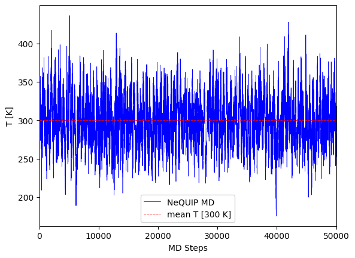

```python
plt.plot(nfi,temp, color='blue', lw=0.5, label='NeQUIP MD')
plt.axhline(y = 300.0, color = 'r', lw=0.7, linestyle = '--', label="mean T [300 K]")

plt.xlim([0,len(nfi)])

plt.xlabel('MD Steps')
plt.ylabel('T [K]')

plt.legend()
plt.show()
```

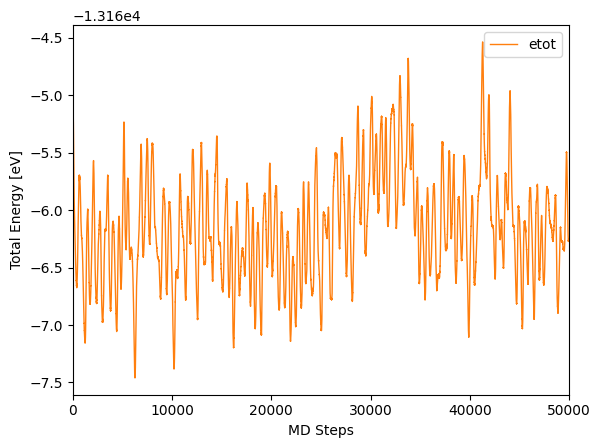

```python
plt.plot(nfi,etot, color='tab:orange', lw=1.0, label='etot')

plt.xlim([0,len(nfi)])

plt.xlabel('MD Steps')
plt.ylabel('Total Energy [eV]')

plt.legend()
plt.show()
```

## Radial Distribution Function (RDF)

```python
!ls *.dat
```

```
gofr_HH.dat gofr_OH.dat gofr_OO.dat
```

```python
dat_OO = np.loadtxt('gofr_OO.dat', delimiter=' ')
x1 = dat_OO[:,0]
y1 = dat_OO[:,1]
#
dat_OH = np.loadtxt('gofr_OH.dat', delimiter=' ')
x2 = dat_OH[:,0]
y2 = dat_OH[:,1]
#
dat_HH = np.loadtxt('gofr_HH.dat', delimiter=' ')
x3 = dat_HH[:,0]
y3 = dat_HH[:,1]
```

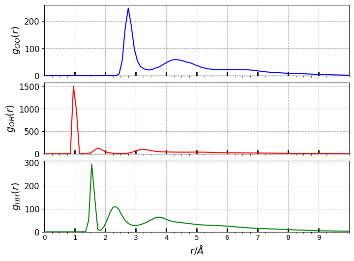

```python
# Define figure size
fig, ax = plt.subplots(3, 1, figsize=(8, 6), sharex=True)

# Adjust layout
fig.subplots_adjust(hspace=0.1)

# Plot data
ax[0].plot(x1, y1, color='blue')
ax[0].set_ylabel(r'$g_{OO}(r)$')
ax[0].set_xlim([0, 10])
ax[0].set_ylim([0, None])
ax[0].grid(True, linestyle='--')

ax[1].plot(x2, y2, color='red')
ax[1].set_ylabel(r'$g_{OH}(r)$')
ax[1].set_ylim([0, None])
ax[1].grid(True, linestyle='--')

ax[2].plot(x3, y3, color='green')
ax[2].set_ylabel(r'$g_{HH}(r)$')
ax[2].set_xlabel(r'$r/\AA$')
ax[2].set_ylim([0, None])
ax[2].grid(True, linestyle='--')

# Adjust tick parameters
for axes in ax:
    axes.xaxis.set_minor_locator(plt.MultipleLocator(0.25))
    axes.set_xticks(np.arange(0, 10.0, 1.0))
    axes.tick_params(axis='x', direction='in', length=6, width=2)
    axes.tick_params(axis='y', labelsize=12)

# Adjust font size
for axes in ax:
    axes.xaxis.label.set_size(14)
    axes.yaxis.label.set_size(14)

plt.show()
```

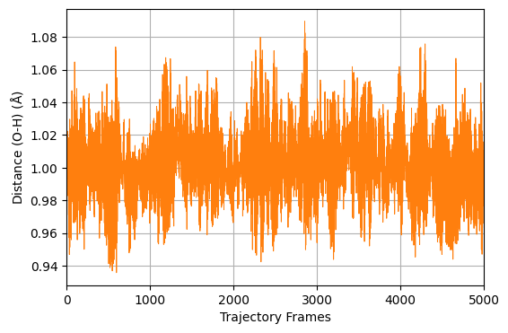

```
Mean distance between atom 18 and atom 53: 1.0025 A
```

```python
import MDAnalysis as mda

# Load the trajectory file
universe = mda.Universe("water.xyz")

# Define the selection of the two atoms by their indices
atom1_index = 18  # Modify this to the actual index of atom 1
atom2_index = 53  # Modify this to the actual index of atom 2

# List to store distances for each frame
distances = []
time = []
t = 0

# Looping Through Frames
for ts in universe.trajectory:
  # Get the coordinates directly
  coords1 = universe.atoms[atom1_index].position
  coords2 = universe.atoms[atom2_index].position

  # Calculate the distance between the two atoms
  distance = np.linalg.norm(coords1 - coords2)

  # Append distance to the list
  distances.append(distance)

  # count no. of Frames in trajectory
  t += 1
  time.append(t)

# Plotting the results
plt.figure(figsize=(6, 4))
plt.plot(time, distances, marker=' ', linestyle='-', color='tab:orange', lw=0.7)

plt.xlim([0, len(distances)])
plt.xlabel("Trajectory Frames")
plt.ylabel(r"Distance (O-H) $(\rm{\AA})$")
plt.grid(True)
plt.show()

# Calculate and print the mean distance
nequip_mean_dist = np.mean(distances)
print(f"Mean distance between atom {atom1_index} and atom {atom2_index}: {nequip_mean_dist:.4f} A")
```

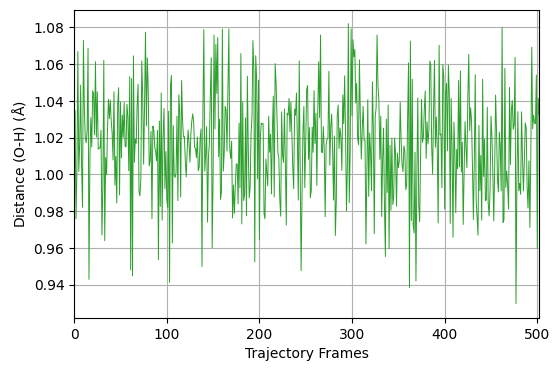

```
Mean distance between atom 18 and atom 19: 1.0166 A
```

```python
import MDAnalysis as mda
import numpy as np  # Import NumPy

# Load the trajectory file
qe_data = mda.Universe("qe_traj.xyz")

# Define the selection of the two atoms by their indices
atom1_index = 18  # Modify this to the actual index of atom 1
atom2_index = 19  # Modify this to the actual index of atom 2

# List to store distances for each frame
distances = []
tt = []
t = 0

# Looping Through Frames
for ts in qe_data.trajectory:
    # Get the coordinates directly
    coords1 = qe_data.atoms[atom1_index].position
    coords2 = qe_data.atoms[atom2_index].position

    # Calculate the distance between the two atoms
    distance = np.linalg.norm(coords1 - coords2)

    # Append distance to the list
    distances.append(distance)

    # count no. of Frames in trajectory
    t += 1
    tt.append(t)

# Plotting the results
plt.figure(figsize=(6, 4))
plt.plot(tt, distances, marker=' ', linestyle='-', color='tab:green', lw=0.7)

plt.xlim([0, len(distances)])
plt.xlabel("Trajectory Frames")
plt.ylabel(r"Distance (O-H) $(\rm{\AA})$")
plt.grid(True)
plt.show()

# Calculate and print the mean distance
qe_mean_dist = np.mean(distances)
print(f"Mean distance between atom {atom1_index} and atom {atom2_index}: {qe_mean_dist:.4f} A")
```